# Tonnetz vs Chroma vs PCA for Automatic Chord Estimation

### 8d. Musically-aware error metrics

**TWE (Tonnetz-Weighted Error):** penalises misclassifications by geometric Tonnetz distance between roots.

**MCE (Mechanical-Consonance Error):** penalises by perceptual dissonance score from the consonance vector. Lower = better for both.

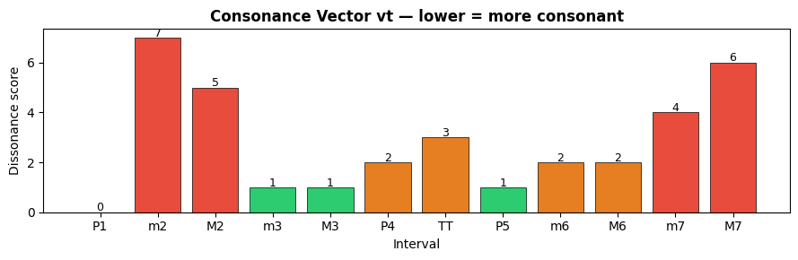

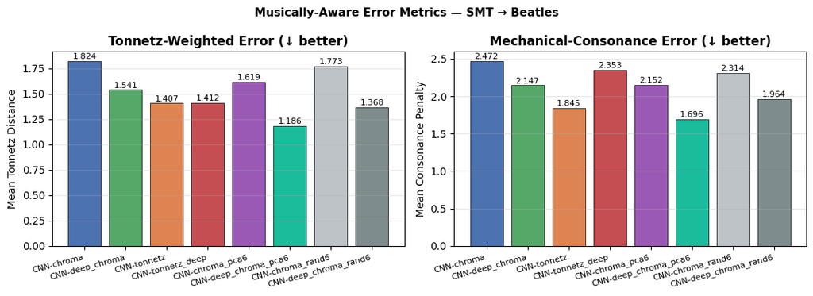

```python
# Visualise consonance vector
interval_names = ['P1','m2','M2','m3','M3','P4','TT','P5','m6','M6','m7','M7']
fig, ax = plt.subplots(figsize=(9,3))
bar_colors = ['#2ecc71' if v<=1 else '#e67e22' if v<=3 else '#e74c3c'
              for v in CONSONANCE_VEC]
bars = ax.bar(interval_names, CONSONANCE_VEC, color=bar_colors,
              edgecolor='black', linewidth=0.5)
for bar,v in zip(bars, CONSONANCE_VEC):
    ax.text(bar.get_x()+bar.get_width()/2, v+0.05, str(int(v)),
            ha='center', fontsize=9)
ax.set_title('Consonance Vector vt — lower = more consonant',
             fontweight='bold')
ax.set_ylabel('Dissonance score'); ax.set_xlabel('Interval')
plt.tight_layout()
plt.savefig(str(OUT_DIR / 'consonance_vector.png'), dpi=150); plt.show()

# TWE and MCE comparison
fig, axes = plt.subplots(1,2, figsize=(11,4))
for ax, key, title, ylabel in zip(axes,
    ['twe',                    'mce'],
    ['Tonnetz-Weighted Error', 'Mechanical-Consonance Error'],
    ['Mean Tonnetz Distance',  'Mean Consonance Penalty']):
    vals = [results[r][key] for r in ALL_REP_DIMS]
    bars = ax.bar(labels, vals, color=[ALL_COLORS.get(r, "#333") for r in ALL_REP_DIMS],
                  edgecolor='black', linewidth=0.5)
    ax.set_title(f'{title} (↓ better)', fontweight='bold')
    ax.set_ylabel(ylabel)
    for bar,v in zip(bars,vals):
        ax.text(bar.get_x()+bar.get_width()/2, v+max(vals)*0.01, f'{v:.3f}',
                ha='center', fontsize=8)
    ax.set_xticklabels(labels, rotation=15, ha='right', fontsize=8)
    ax.grid(axis='y', alpha=0.3)
plt.suptitle('Musically-Aware Error Metrics — SMT → Beatles',
             fontsize=11, fontweight='bold')
plt.tight_layout()
plt.savefig(str(OUT_DIR / 'musical_error_metrics.png'), dpi=150); plt.show()
```

### 8e. Confusion matrices (Beatles test)

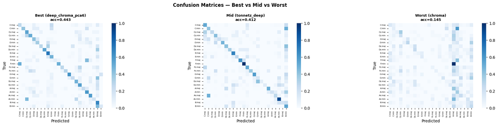

```python
# ── Focused confusion matrices: best, mid-tier, worst + difference ────────────
focus_reps = ['deep_chroma_pca6', 'tonnetz_deep', 'chroma']
focus_labels = ['Best (deep_chroma_pca6)', 'Mid (tonnetz_deep)', 'Worst (chroma)']

fig, axes = plt.subplots(1, 3, figsize=(20, 4.5))

# Individual CMs for 3 key models
cms_norm = {}
for ax, rep, label in zip(axes[:3], focus_reps, focus_labels):
    cm      = confusion_matrix(results[rep]['targets'], results[rep]['preds'])
    cm_n = cm.astype(float) / cm.sum(axis=1, keepdims=True).clip(min=1)
    cms_norm[rep] = cm_n
    sns.heatmap(cm_n, ax=ax, cmap='Blues', vmin=0, vmax=1,
                xticklabels=CHORD_LABELS, yticklabels=CHORD_LABELS,
                cbar=True, square=True)
    ax.set_title(f'{label}\nacc={results[rep]["acc"]:.3f}', fontweight='bold', fontsize=9)
    ax.set_xlabel('Predicted'); ax.set_ylabel('True')
    ax.tick_params(labelsize=5)
    plt.setp(ax.get_xticklabels(), rotation=90)
    plt.setp(ax.get_yticklabels(), rotation=0)


plt.suptitle('Confusion Matrices — Best vs Mid vs Worst', fontweight='bold')
plt.tight_layout()
plt.savefig(str(OUT_DIR / 'confusion_matrices_focused.png'), dpi=150); plt.show()
```

### 8f. Per-root × per-quality accuracy heatmap

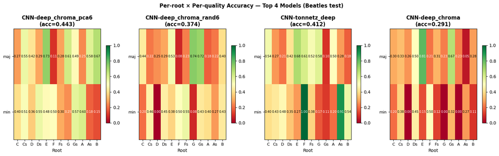

```python
# ── Per-root × per-quality accuracy heatmap — top 4 models only ───────────────
focus_reps_4 = ['deep_chroma_pca6', 'deep_chroma_rand6', 'tonnetz_deep', 'deep_chroma']
n = len(focus_reps_4)
fig, axes = plt.subplots(1, n, figsize=(4*n, 5))
for ax, rep in zip(axes, focus_reps_4):
    matrix = np.array([
        [(results[rep]['preds'][results[rep]['targets']==LABEL2IDX[f'{r}:{q}']] ==
          LABEL2IDX[f'{r}:{q}']).mean()
         if (results[rep]['targets']==LABEL2IDX[f'{r}:{q}']).sum() > 0
         else np.nan
         for q in QUALITIES] for r in ROOTS
    ])  # (12,2)
    im = ax.imshow(matrix.T, aspect='auto', cmap='RdYlGn', vmin=0, vmax=1)
    ax.set_xticks(range(12)); ax.set_xticklabels(ROOTS, fontsize=9)
    ax.set_yticks(range(2));  ax.set_yticklabels(QUALITIES, fontsize=9)
    ax.set_title(f'CNN-{rep}\n(acc={results[rep]["acc"]:.3f})', fontweight='bold')
    ax.set_xlabel('Root')
    for i in range(12):
        for j in range(2):
            v = matrix[i,j]
            if not np.isnan(v):
                ax.text(i, j, f'{v:.2f}', ha='center', va='center',
                        fontsize=7, color='black' if 0.25<v<0.8 else 'white')
    plt.colorbar(im, ax=ax, shrink=0.7)
plt.suptitle('Per-root × Per-quality Accuracy — Top 4 Models (Beatles test)',
             fontsize=12, fontweight='bold')
plt.tight_layout()
plt.savefig(str(OUT_DIR / 'per_root_accuracy_focused.png'), dpi=150); plt.show()
```

### 8g. Major vs minor macro F1 — quality gap analysis

```
Major vs Minor Macro F1:
Model                   Maj F1    Min F1       Gap
--------------------------------------------------
CNN-chroma              0.1376    0.1864   -0.0488
CNN-deep_chroma         0.3328    0.2498    0.0830
CNN-tonnetz             0.3087    0.3399   -0.0312
CNN-tonnetz_deep        0.4683    0.4292    0.0392
CNN-chroma_pca6         0.2633    0.1925    0.0708
CNN-deep_chroma_pca6    0.4952    0.5094   -0.0142
CNN-chroma_rand6        0.1979    0.1790    0.0189
CNN-deep_chroma_rand6    0.3931    0.4448   -0.0517
```

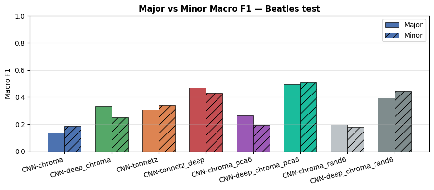

```python
print('Major vs Minor Macro F1:')
print(f'{"Model":<20s}  {"Maj F1":>8s}  {"Min F1":>8s}  {"Gap":>8s}')
print('-'*50)
for rep in ALL_REP_DIMS:
    mj = results[rep]['maj_f1']; mn = results[rep]['min_f1']
    print(f'CNN-{rep:<16s}  {mj:8.4f}  {mn:8.4f}  {mj-mn:8.4f}')

fig, ax = plt.subplots(figsize=(9,4))
x   = np.arange(len(ALL_REP_DIMS)); w = 0.35
ax.bar(x-w/2, [results[r]['maj_f1'] for r in ALL_REP_DIMS], w,
       label='Major', color=[ALL_COLORS.get(r, '#333') for r in ALL_REP_DIMS], edgecolor='black', lw=0.5)
ax.bar(x+w/2, [results[r]['min_f1'] for r in ALL_REP_DIMS], w,
       label='Minor', color=[ALL_COLORS.get(r, '#333') for r in ALL_REP_DIMS], edgecolor='black', lw=0.5,
       hatch='//')
ax.set_xticks(x); ax.set_xticklabels([f'CNN-{r}' for r in ALL_REP_DIMS],
                                      rotation=15, ha='right')
ax.set_ylabel('Macro F1'); ax.set_ylim(0,1)
ax.set_title('Major vs Minor Macro F1 — Beatles test', fontweight='bold')
ax.legend(); ax.grid(axis='y', alpha=0.3)
plt.tight_layout()
plt.savefig(str(OUT_DIR / 'maj_min_f1.png'), dpi=150); plt.show()
```

### 8g-bis. Error-type decomposition: root vs quality errors

For each misclassification, we decompose into three categories: correct root but wrong quality, wrong root but correct quality, or both wrong. This directly tests whether Tonnetz/PCA helps quality discrimination.

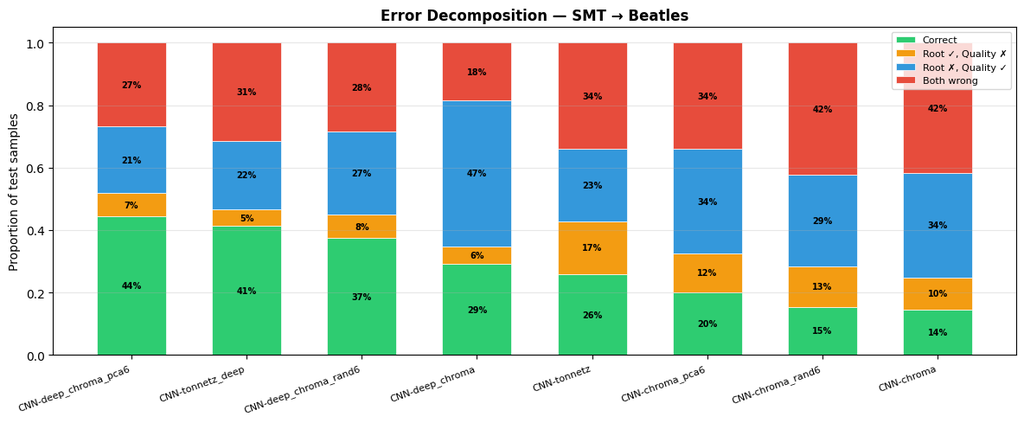

```
Error decomposition (sorted by Macro F1):
Model                       Correct  Qual Err  Root Err      Both
-----------------------------------------------------------------
CNN-deep_chroma_pca6          44.3%      7.4%     21.4%     26.8%
CNN-tonnetz_deep              41.2%      5.3%     22.1%     31.4%
CNN-deep_chroma_rand6         37.4%      7.5%     26.7%     28.4%
CNN-deep_chroma               29.1%      5.5%     47.0%     18.4%
CNN-tonnetz                   25.8%     17.1%     23.2%     33.9%
CNN-chroma_pca6               20.2%     12.3%     33.5%     34.0%
CNN-chroma_rand6              15.4%     12.8%     29.4%     42.4%
CNN-chroma                    14.5%     10.3%     33.6%     41.6%
```

```python
# ── Error-type decomposition ───────────────────────────────────────────────────
def error_decomposition(preds, targets):
    """Decompose errors into root-only, quality-only, and both-wrong."""
    correct = root_err = qual_err = both_err = 0
    for p, t in zip(preds, targets):
        p_root, p_qual = IDX2LABEL[p].split(':')
        t_root, t_qual = IDX2LABEL[t].split(':')
        if p == t:
            correct += 1
        elif p_root == t_root and p_qual != t_qual:
            qual_err += 1   # correct root, wrong quality
        elif p_root != t_root and p_qual == t_qual:
            root_err += 1   # wrong root, correct quality
        else:
            both_err += 1   # both wrong
    n = len(preds)
    return {'correct': correct/n, 'quality_err': qual_err/n,
            'root_err': root_err/n, 'both_err': both_err/n}

decomp = {rep: error_decomposition(results[rep]['preds'], results[rep]['targets'])
           for rep in ALL_REP_DIMS}

# Sort by macro F1 for clearer visual
sorted_reps = sorted(ALL_REP_DIMS.keys(), key=lambda r: results[r]['macro_f1'], reverse=True)

fig, ax = plt.subplots(figsize=(12, 5))
x = np.arange(len(sorted_reps))
w = 0.6
bottoms = np.zeros(len(sorted_reps))

err_types = [
    ('correct',     '#2ecc71', 'Correct'),
    ('quality_err', '#f39c12', 'Root ✓, Quality ✗'),
    ('root_err',    '#3498db', 'Root ✗, Quality ✓'),
    ('both_err',    '#e74c3c', 'Both wrong'),
]
for key, color, label in err_types:
    vals = [decomp[r][key] for r in sorted_reps]
    ax.bar(x, vals, w, bottom=bottoms, label=label, color=color,
           edgecolor='white', linewidth=0.5)
    # Label segments > 5%
    for i, v in enumerate(vals):
        if v > 0.05:
            ax.text(x[i], bottoms[i] + v/2, f'{v:.0%}',
                    ha='center', va='center', fontsize=7, fontweight='bold')
    bottoms += vals

ax.set_xticks(x)
ax.set_xticklabels([f'CNN-{r}' for r in sorted_reps], rotation=20, ha='right', fontsize=8)
ax.set_ylabel('Proportion of test samples')
ax.set_title('Error Decomposition — SMT → Beatles', fontweight='bold')
ax.legend(loc='upper right', fontsize=8)
ax.set_ylim(0, 1.05)
ax.grid(axis='y', alpha=0.3)
plt.tight_layout()
plt.savefig(str(OUT_DIR / 'error_decomposition.png'), dpi=150); plt.show()

print('\nError decomposition (sorted by Macro F1):')
print(f'{"Model":<25s}  {"Correct":>8s}  {"Qual Err":>8s}  {"Root Err":>8s}  {"Both":>8s}')
print('-'*65)
for rep in sorted_reps:
    d = decomp[rep]
    print(f'CNN-{rep:<21s}  {d["correct"]:8.1%}  {d["quality_err"]:8.1%}  '
          f'{d["root_err"]:8.1%}  {d["both_err"]:8.1%}')
```

## 8. Filter Visualisation

```python
def _is_quality_filter(fdata, thresh_frac=0.4):
    p = fdata.mean(axis=0)
    m3 = p[2]+p[3]; M3 = p[4]+p[5]
    t  = thresh_frac * np.abs(p).max()
    return (abs(m3)>t and abs(M3)>t and np.sign(m3)!=np.sign(M3))

def _is_fifth_filter(fdata, thresh_frac=0.4):
    p  = fdata.mean(axis=0)
    p5 = p[0]+p[1]; m3 = p[2]+p[3]; M3 = p[4]+p[5]
    t  = thresh_frac * np.abs(p).max()
    return (abs(p5)>t and abs(p5)>abs(m3) and abs(p5)>abs(M3))
```

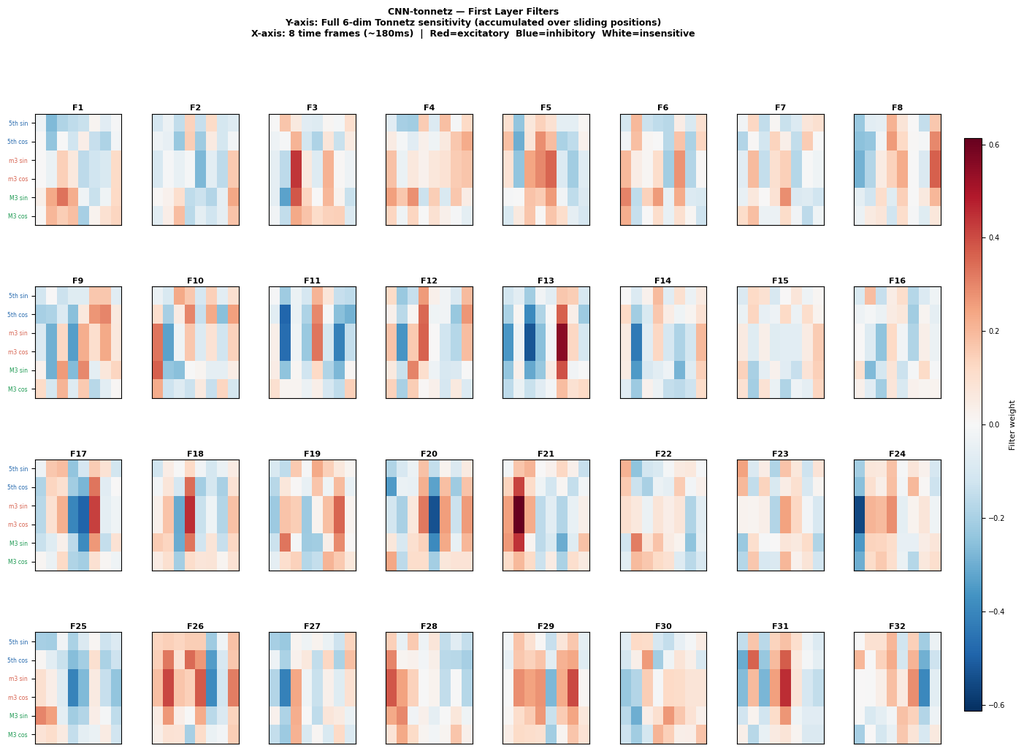

```
CNN-tonnetz:  mean|w|=0.1005  max|w|=0.2986
```

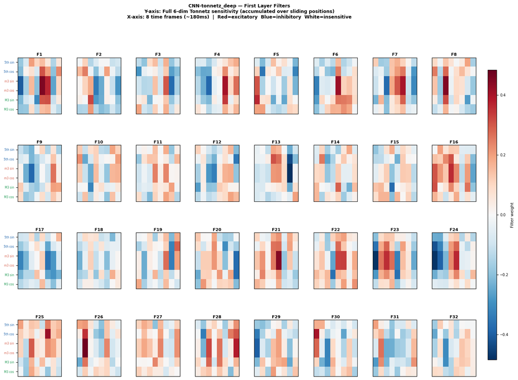

```
CNN-tonnetz_deep:  mean|w|=0.1032  max|w|=0.2484
```

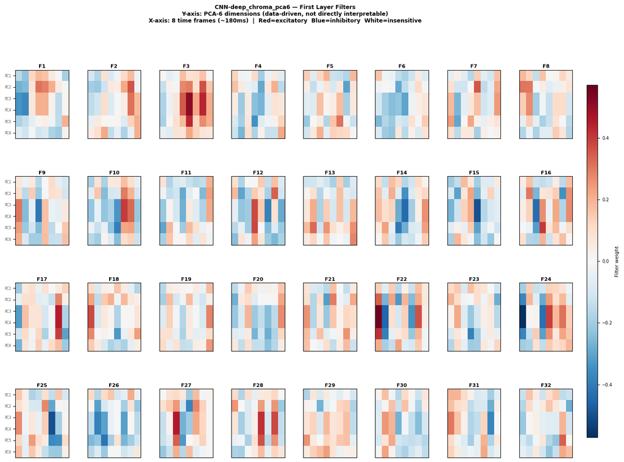

```
CNN-deep_chroma_pca6:  mean|w|=0.1070  max|w|=0.2798
```

```python
# ── Labelled filter grids — Tonnetz models only + deep_chroma_pca6 comparison ─

from matplotlib.patches import FancyArrowPatch
import matplotlib.gridspec as gridspec

TONNETZ_AXIS_LABELS = ['5th sin','5th cos','m3 sin','m3 cos','M3 sin','M3 cos']
TONNETZ_AXIS_COLORS = ['#2166ac','#2166ac','#d6604d','#d6604d','#1a9850','#1a9850']

def compute_full_sensitivity(filters, n_feat=6, kernel_w=3):
    n_pos    = n_feat - kernel_w + 1
    full     = np.zeros((filters.shape[0], filters.shape[1], n_feat))
    for pos in range(n_pos):
        full[:, :, pos:pos+kernel_w] += filters
    return full

# Show only interpretable models: tonnetz, tonnetz_deep, and deep_chroma_pca6 for comparison
FILTER_VIS_REPS = ['tonnetz', 'tonnetz_deep', 'deep_chroma_pca6']

for rep in FILTER_VIS_REPS:
    filters  = trained_models[rep].get_first_layer_filters()   # (32, 8, 3)
    is_tz    = 'tonnetz' in rep

    if is_tz:
        plot_data = compute_full_sensitivity(filters, n_feat=6, kernel_w=3)
        feat_labels = TONNETZ_AXIS_LABELS
        feat_colors = TONNETZ_AXIS_COLORS
        feat_desc   = 'Full 6-dim Tonnetz sensitivity (accumulated over sliding positions)'
    else:
        plot_data = compute_full_sensitivity(filters, n_feat=6, kernel_w=3)
        feat_labels = [f'PC{i+1}' for i in range(6)]
        feat_colors = ['#555555'] * 6
        feat_desc   = 'PCA-6 dimensions (data-driven, not directly interpretable)'

    vmax = np.abs(plot_data).max()
    ncols_grid = 8
    nrows_grid = 4

    fig, axes = plt.subplots(
        nrows_grid, ncols_grid,
        figsize=(ncols_grid * 2.0, nrows_grid * 2.8),
        gridspec_kw={'hspace': 0.55, 'wspace': 0.35}
    )

    for idx, ax in enumerate(axes.flatten()):
        fdata = plot_data[idx]
        im = ax.imshow(fdata.T, aspect='auto',
                       cmap='RdBu_r', vmin=-vmax, vmax=vmax,
                       interpolation='nearest')
        ax.set_title(f'F{idx+1}', fontsize=8, fontweight='bold', pad=3)
        ax.set_xticks([]); ax.set_yticks([])

        if idx % ncols_grid == 0:
            ax.set_yticks(range(len(feat_labels)))
            ax.set_yticklabels(feat_labels, fontsize=5.5)
            for tick, color in zip(ax.get_yticklabels(), feat_colors):
                tick.set_color(color)

        if is_tz:
            profile = fdata.mean(axis=0)
            m3_score = float(profile[2] + profile[3])
            M3_score = float(profile[4] + profile[5])
            p5_score = float(profile[0] + profile[1])
            max_abs   = np.abs(profile).max()
            thresh    = 0.4 * max_abs
            opponent  = (abs(m3_score) > thresh and abs(M3_score) > thresh
                         and np.sign(m3_score) != np.sign(M3_score))
            fifth_dom = (abs(p5_score) > thresh
                         and abs(p5_score) > abs(m3_score)
                         and abs(p5_score) > abs(M3_score))


    cbar_ax = fig.add_axes([0.92, 0.15, 0.015, 0.7])
    sm = plt.cm.ScalarMappable(cmap='RdBu_r',
                               norm=plt.Normalize(vmin=-vmax, vmax=vmax))
    sm.set_array([])
    cb = fig.colorbar(sm, cax=cbar_ax)
    cb.set_label('Filter weight', fontsize=8)
    cb.ax.tick_params(labelsize=7)



    fig.suptitle(
        f'CNN-{rep} — First Layer Filters\n'
        f'Y-axis: {feat_desc}\n'
        f'X-axis: 8 time frames (~180ms)  |  '
        f'Red=excitatory  Blue=inhibitory  White=insensitive',
        fontsize=9, fontweight='bold', y=1.01
    )

    plt.savefig(str(OUT_DIR / f'filters_labelled_{rep}.png'),
                dpi=150, bbox_inches='tight')
    plt.show()
    print(f'CNN-{rep}:  mean|w|={np.abs(filters).mean():.4f}  '
          f'max|w|={np.abs(filters).max():.4f}')
```

## 9. Cross-Dataset Experiment Matrix

Seven transfer experiments spanning three corpora (SMT synth, Beatles pop, Schubert classical) to test whether representation rankings are stable across musical domains.

| # | Train | Test | Tests |
| --- | --- | --- | --- |
| E1 | SMT | Beatles | Synth → pop |
| E2 | Beatles | SMT | Pop → synth (reverse) |
| E3 | SMT | Schubert (SC06) | Synth → classical |
| E4 | Schubert (SC06) | SMT | Classical → synth |
| E5 | SMT | All real (Beatles + Schubert) | Synth → mixed real |
| E6 | All real (Beatles + Schubert) | SMT | Mixed real → synth |
| E7 | SMT + Schubert-train + Revolver | Schubert-test + Sgt Pepper's | Mixed holdout (cross-genre) |

**Data isolation in E7:** Schubert is split by piece number (pieces 1–12 train, 13–24 test), Beatles by album (Revolver train, Sgt Pepper's test). No segment appears in both train and test.

### E2: Beatles → SMT (reverse transfer)

```python
print('E2: Train=Beatles  Test=SMT')
exp_e2_res, _ = run_experiment(beatles_data, smt_data, 'E2_Beatles_to_SMT')
df_e2 = summarise(exp_e2_res, 'E2 Beatles→SMT')
```

```
E2: Train=Beatles  Test=SMT
  [E2_Beatles_to_SMT] CNN-chroma...
  epoch  10/40  train=2.4593  val=2.8687  acc=0.1584
  epoch  20/40  train=1.7090  val=3.6453  acc=0.1650
  epoch  30/40  train=1.3139  val=2.6376  acc=0.2838
  epoch  40/40  train=1.2542  val=2.0620  acc=0.4026
    acc=0.1300  macro_f1=0.0877  maj_f1=0.2125  min_f1=0.0281
  [E2_Beatles_to_SMT] CNN-deep_chroma...
  epoch  10/40  train=2.1357  val=2.2898  acc=0.2706
  epoch  20/40  train=1.3525  val=2.0266  acc=0.4356
  epoch  30/40  train=1.0139  val=1.3875  acc=0.6370
  epoch  40/40  train=0.9451  val=1.2914  acc=0.6601
    acc=0.2395  macro_f1=0.1909  maj_f1=0.3875  min_f1=0.1208
  [E2_Beatles_to_SMT] CNN-tonnetz...
  epoch  10/40  train=1.5946  val=2.1228  acc=0.3828
  epoch  20/40  train=0.9531  val=2.7755  acc=0.3366
  epoch  30/40  train=0.6407  val=1.8264  acc=0.5149
  epoch  40/40  train=0.5657  val=1.7249  acc=0.5347
    acc=0.3422  macro_f1=0.2654  maj_f1=0.5302  min_f1=0.1690
  [E2_Beatles_to_SMT] CNN-tonnetz_deep...
  epoch  10/40  train=0.8162  val=1.0084  acc=0.7426
  epoch  20/40  train=0.4005  val=0.6182  acc=0.8185
  epoch  30/40  train=0.2790  val=0.6068  acc=0.8449
  epoch  40/40  train=0.2454  val=0.5602  acc=0.8482
    acc=0.7547  macro_f1=0.7205  maj_f1=0.9233  min_f1=0.6767
  [E2_Beatles_to_SMT] CNN-chroma_pca6...
  epoch  10/40  train=1.8533  val=2.6020  acc=0.2904
  epoch  20/40  train=1.1701  val=3.3705  acc=0.2343
  epoch  30/40  train=0.8012  val=2.4109  acc=0.3960
  epoch  40/40  train=0.7536  val=1.9736  acc=0.4686
    acc=0.1819  macro_f1=0.1265  maj_f1=0.3340  min_f1=0.0306
  [E2_Beatles_to_SMT] CNN-deep_chroma_pca6...
  epoch  10/40  train=0.9796  val=1.2120  acc=0.6436
  epoch  20/40  train=0.5125  val=1.3797  acc=0.6139
  epoch  30/40  train=0.3095  val=0.6755  acc=0.8020
  epoch  40/40  train=0.2453  val=0.6313  acc=0.8251
    acc=0.6069  macro_f1=0.5508  maj_f1=0.8234  min_f1=0.4679
  [E2_Beatles_to_SMT] CNN-chroma_rand6...
  epoch  10/40  train=1.8793  val=2.5223  acc=0.2937
  epoch  20/40  train=1.1668  val=2.3129  acc=0.3498
  epoch  30/40  train=0.7855  val=1.8313  acc=0.4554
  epoch  40/40  train=0.7507  val=1.8175  acc=0.4917
    acc=0.2280  macro_f1=0.1697  maj_f1=0.3456  min_f1=0.1149
  [E2_Beatles_to_SMT] CNN-deep_chroma_rand6...
  epoch  10/40  train=1.0057  val=1.1462  acc=0.6601
  epoch  20/40  train=0.4756  val=1.5013  acc=0.5644
  epoch  30/40  train=0.2689  val=0.8181  acc=0.7723
  epoch  40/40  train=0.2237  val=0.6867  acc=0.8086
    acc=0.5624  macro_f1=0.5238  maj_f1=0.7896  min_f1=0.4365

E2 Beatles→SMT
                Model  Accuracy  Macro F1  Maj F1  Min F1    TWE    MCE
     CNN-tonnetz_deep    0.7547    0.7205  0.9233  0.6767 0.5215 0.8061
 CNN-deep_chroma_pca6    0.6069    0.5508  0.8234  0.4679 0.9303 1.1116
CNN-deep_chroma_rand6    0.5624    0.5238  0.7896  0.4365 0.9603 1.2364
          CNN-tonnetz    0.3422    0.2654  0.5302  0.1690 1.1682 1.6478
      CNN-deep_chroma    0.2395    0.1909  0.3875  0.1208 1.6887 2.2914
     CNN-chroma_rand6    0.2280    0.1697  0.3456  0.1149 1.5265 1.9796
      CNN-chroma_pca6    0.1819    0.1265  0.3340  0.0306 1.6589 2.3506
           CNN-chroma    0.1300    0.0877  0.2125  0.0281 1.8896 2.7196
```

### E3: SMT → Schubert

```python
print('E3: Train=SMT  Test=Schubert')
exp_e3_res, _ = run_experiment(smt_data, schubert_data, 'E3_SMT_to_Schubert')
df_e3 = summarise(exp_e3_res, 'E3 SMT→Schubert')
```

```
E3: Train=SMT  Test=Schubert
  [E3_SMT_to_Schubert] CNN-chroma...
  epoch  10/40  train=2.0249  val=1.9770  acc=0.3937
  epoch  20/40  train=1.3298  val=1.6728  acc=0.4226
  epoch  30/40  train=1.0413  val=1.2750  acc=0.5879
  epoch  40/40  train=0.9578  val=1.1053  acc=0.7060
    acc=0.1225  macro_f1=0.1027  maj_f1=0.1234  min_f1=0.1589
  [E3_SMT_to_Schubert] CNN-deep_chroma...
  epoch  10/40  train=1.0149  val=1.5142  acc=0.5459
  epoch  20/40  train=0.5376  val=0.7094  acc=0.8451
  epoch  30/40  train=0.3549  val=0.5141  acc=0.8924
  epoch  40/40  train=0.3028  val=0.4953  acc=0.8871
    acc=0.1527  macro_f1=0.1116  maj_f1=0.1725  min_f1=0.0851
  [E3_SMT_to_Schubert] CNN-tonnetz...
  epoch  10/40  train=0.7594  val=0.9438  acc=0.7402
  epoch  20/40  train=0.3466  val=1.0088  acc=0.7402
  epoch  30/40  train=0.2169  val=0.6802  acc=0.8058
  epoch  40/40  train=0.1815  val=0.6271  acc=0.8215
    acc=0.2200  macro_f1=0.2147  maj_f1=0.2706  min_f1=0.2865
  [E3_SMT_to_Schubert] CNN-tonnetz_deep...
  epoch  10/40  train=0.3891  val=0.5542  acc=0.8924
  epoch  20/40  train=0.2109  val=0.5322  acc=0.9029
  epoch  30/40  train=0.1311  val=0.5427  acc=0.9108
  epoch  40/40  train=0.1023  val=0.5175  acc=0.9081
    acc=0.2515  macro_f1=0.2239  maj_f1=0.2877  min_f1=0.2741
  [E3_SMT_to_Schubert] CNN-chroma_pca6...
  epoch  10/40  train=0.7820  val=1.0043  acc=0.7087
  epoch  20/40  train=0.4091  val=0.8529  acc=0.7848
  epoch  30/40  train=0.2678  val=0.6056  acc=0.8373
  epoch  40/40  train=0.2162  val=0.5306  acc=0.8583
    acc=0.2246  macro_f1=0.2011  maj_f1=0.2690  min_f1=0.2450
  [E3_SMT_to_Schubert] CNN-deep_chroma_pca6...
  epoch  10/40  train=0.5276  val=0.6939  acc=0.8320
  epoch  20/40  train=0.2695  val=0.5645  acc=0.8583
  epoch  30/40  train=0.1539  val=0.4441  acc=0.8898
  epoch  40/40  train=0.1302  val=0.4252  acc=0.9081
    acc=0.2065  macro_f1=0.1871  maj_f1=0.2234  min_f1=0.2465
  [E3_SMT_to_Schubert] CNN-chroma_rand6...
  epoch  10/40  train=1.0442  val=1.9419  acc=0.3885
  epoch  20/40  train=0.5435  val=1.8202  acc=0.5092
  epoch  30/40  train=0.3896  val=1.0095  acc=0.7297
  epoch  40/40  train=0.3099  val=0.8015  acc=0.7848
    acc=0.1425  macro_f1=0.1352  maj_f1=0.1530  min_f1=0.2072
  [E3_SMT_to_Schubert] CNN-deep_chroma_rand6...
  epoch  10/40  train=0.5298  val=0.7312  acc=0.8189
  epoch  20/40  train=0.2583  val=0.5994  acc=0.8609
  epoch  30/40  train=0.1477  val=0.4993  acc=0.8924
  epoch  40/40  train=0.1207  val=0.4876  acc=0.8976
    acc=0.1791  macro_f1=0.1603  maj_f1=0.2155  min_f1=0.1830

E3 SMT→Schubert
                Model  Accuracy  Macro F1  Maj F1  Min F1    TWE    MCE
     CNN-tonnetz_deep    0.2515    0.2239  0.2877  0.2741 1.7155 2.5935
          CNN-tonnetz    0.2200    0.2147  0.2706  0.2865 1.6883 2.4529
      CNN-chroma_pca6    0.2246    0.2011  0.2690  0.2450 1.6996 2.2937
 CNN-deep_chroma_pca6    0.2065    0.1871  0.2234  0.2465 1.7780 2.5211
CNN-deep_chroma_rand6    0.1791    0.1603  0.2155  0.1830 1.9117 2.7907
     CNN-chroma_rand6    0.1425    0.1352  0.1530  0.2072 1.9433 2.7633
      CNN-deep_chroma    0.1527    0.1116  0.1725  0.0851 1.9178 2.7258
           CNN-chroma    0.1225    0.1027  0.1234  0.1589 1.9381 2.7197
```

### E4: Schubert → SMT (reverse)

```python
print('E4: Train=Schubert  Test=SMT')
exp_e4_res, _ = run_experiment(schubert_data, smt_data, 'E4_Schubert_to_SMT')
df_e4 = summarise(exp_e4_res, 'E4 Schubert→SMT')
```

```
E4: Train=Schubert  Test=SMT
  [E4_Schubert_to_SMT] CNN-chroma...
  epoch  10/40  train=2.8266  val=3.0141  acc=0.0905
  epoch  20/40  train=2.3205  val=3.8222  acc=0.0951
  epoch  30/40  train=1.9348  val=2.9245  acc=0.1671
  epoch  40/40  train=1.8246  val=2.8167  acc=0.1671
    acc=0.1305  macro_f1=0.0843  maj_f1=0.1867  min_f1=0.0541
  [E4_Schubert_to_SMT] CNN-deep_chroma...
  epoch  10/40  train=2.8173  val=2.9139  acc=0.1253
  epoch  20/40  train=2.4509  val=2.7933  acc=0.1624
  epoch  30/40  train=2.1844  val=2.4801  acc=0.2715
  epoch  40/40  train=2.0943  val=2.4520  acc=0.2807
    acc=0.1777  macro_f1=0.1019  maj_f1=0.1663  min_f1=0.1180
  [E4_Schubert_to_SMT] CNN-tonnetz...
  epoch  10/40  train=1.9603  val=2.4421  acc=0.2947
  epoch  20/40  train=1.2248  val=2.4629  acc=0.3318
  epoch  30/40  train=0.8546  val=2.7488  acc=0.3155
  epoch  40/40  train=0.7648  val=2.4946  acc=0.3503
    acc=0.4644  macro_f1=0.4123  maj_f1=0.6275  min_f1=0.3877
  [E4_Schubert_to_SMT] CNN-tonnetz_deep...
  epoch  10/40  train=1.4558  val=1.6653  acc=0.5638
  epoch  20/40  train=1.0067  val=1.6362  acc=0.5731
  epoch  30/40  train=0.7190  val=1.5858  acc=0.6102
  epoch  40/40  train=0.6220  val=1.5243  acc=0.6125
    acc=0.7353  macro_f1=0.6889  maj_f1=0.9316  min_f1=0.6113
  [E4_Schubert_to_SMT] CNN-chroma_pca6...
  epoch  10/40  train=2.4526  val=2.9375  acc=0.1369
  epoch  20/40  train=1.7347  val=3.2782  acc=0.1763
  epoch  30/40  train=1.2684  val=3.4999  acc=0.1926
  epoch  40/40  train=1.1660  val=3.1700  acc=0.2065
    acc=0.2222  macro_f1=0.1734  maj_f1=0.2588  min_f1=0.2103
  [E4_Schubert_to_SMT] CNN-deep_chroma_pca6...
  epoch  10/40  train=2.0809  val=2.5108  acc=0.2715
  epoch  20/40  train=1.5471  val=2.0093  acc=0.4246
  epoch  30/40  train=1.2030  val=1.9905  acc=0.4385
  epoch  40/40  train=1.0863  val=1.8492  acc=0.5081
    acc=0.5252  macro_f1=0.4532  maj_f1=0.6858  min_f1=0.4399
  [E4_Schubert_to_SMT] CNN-chroma_rand6...
  epoch  10/40  train=2.3508  val=3.0223  acc=0.1392
  epoch  20/40  train=1.6447  val=3.3612  acc=0.1671
  epoch  30/40  train=1.2203  val=3.2532  acc=0.2111
  epoch  40/40  train=1.0854  val=2.9749  acc=0.2529
    acc=0.2830  macro_f1=0.2430  maj_f1=0.4198  min_f1=0.2188
  [E4_Schubert_to_SMT] CNN-deep_chroma_rand6...
  epoch  10/40  train=1.9258  val=2.4960  acc=0.2923
  epoch  20/40  train=1.3383  val=2.4436  acc=0.3875
  epoch  30/40  train=1.0315  val=2.0150  acc=0.4524
  epoch  40/40  train=0.9091  val=1.9620  acc=0.4664
    acc=0.4717  macro_f1=0.4119  maj_f1=0.7052  min_f1=0.3030

E4 Schubert→SMT
                Model  Accuracy  Macro F1  Maj F1  Min F1    TWE    MCE
     CNN-tonnetz_deep    0.7353    0.6889  0.9316  0.6113 0.5591 0.7788
 CNN-deep_chroma_pca6    0.5252    0.4532  0.6858  0.4399 1.0651 1.2327
          CNN-tonnetz    0.4644    0.4123  0.6275  0.3877 1.0614 1.3538
CNN-deep_chroma_rand6    0.4717    0.4119  0.7052  0.3030 1.1874 1.5881
     CNN-chroma_rand6    0.2830    0.2430  0.4198  0.2188 1.4655 1.8836
      CNN-chroma_pca6    0.2222    0.1734  0.2588  0.2103 1.5479 1.9696
      CNN-deep_chroma    0.1777    0.1019  0.1663  0.1180 1.8474 2.6803
           CNN-chroma    0.1305    0.0843  0.1867  0.0541 1.8424 2.4382
```

### E5: SMT → All real-world (Beatles + Schubert)

Tests generalisation from synth to a heterogeneous real-world mix spanning pop and classical.

```python
print('E5: Train=SMT  Test=All real (Beatles + Schubert)')
exp_e5_res, _ = run_experiment(smt_data, all_real_data, 'E5_SMT_to_AllReal')
df_e5 = summarise(exp_e5_res, 'E5 SMT→AllReal')
```

```
E5: Train=SMT  Test=All real (Beatles + Schubert)
  [E5_SMT_to_AllReal] CNN-chroma...
  epoch  10/40  train=2.1906  val=2.3557  acc=0.2231
  epoch  20/40  train=1.3707  val=2.1671  acc=0.2966
  epoch  30/40  train=1.0464  val=1.2940  acc=0.6063
  epoch  40/40  train=0.9517  val=1.1388  acc=0.6929
    acc=0.1220  macro_f1=0.1097  maj_f1=0.1385  min_f1=0.1626
  [E5_SMT_to_AllReal] CNN-deep_chroma...
  epoch  10/40  train=1.0069  val=1.0779  acc=0.7953
  epoch  20/40  train=0.5050  val=0.7890  acc=0.8320
  epoch  30/40  train=0.3439  val=0.5430  acc=0.8766
  epoch  40/40  train=0.2952  val=0.4859  acc=0.9003
    acc=0.2230  macro_f1=0.2012  maj_f1=0.2788  min_f1=0.1649
  [E5_SMT_to_AllReal] CNN-tonnetz...
  epoch  10/40  train=0.7544  val=1.5240  acc=0.5144
  epoch  20/40  train=0.3446  val=0.9102  acc=0.7638
  epoch  30/40  train=0.2225  val=0.6220  acc=0.8163
  epoch  40/40  train=0.1795  val=0.5824  acc=0.8346
    acc=0.2458  macro_f1=0.2340  maj_f1=0.2991  min_f1=0.3346
  [E5_SMT_to_AllReal] CNN-tonnetz_deep...
  epoch  10/40  train=0.3583  val=0.4754  acc=0.8950
  epoch  20/40  train=0.1895  val=0.4694  acc=0.8976
  epoch  30/40  train=0.1277  val=0.4839  acc=0.9029
  epoch  40/40  train=0.0901  val=0.4745  acc=0.9108
    acc=0.3180  macro_f1=0.3111  maj_f1=0.3818  min_f1=0.3901
  [E5_SMT_to_AllReal] CNN-chroma_pca6...
  epoch  10/40  train=0.8114  val=1.3566  acc=0.5984
  epoch  20/40  train=0.4002  val=0.7428  acc=0.8110
  epoch  30/40  train=0.2493  val=0.6536  acc=0.8189
  epoch  40/40  train=0.2193  val=0.5708  acc=0.8399
    acc=0.2064  macro_f1=0.1998  maj_f1=0.2529  min_f1=0.2944
  [E5_SMT_to_AllReal] CNN-deep_chroma_pca6...
  epoch  10/40  train=0.5401  val=0.8004  acc=0.8110
  epoch  20/40  train=0.2822  val=0.4777  acc=0.8898
  epoch  30/40  train=0.1707  val=0.4755  acc=0.9081
  epoch  40/40  train=0.1418  val=0.4300  acc=0.9134
    acc=0.3057  macro_f1=0.2899  maj_f1=0.3863  min_f1=0.3109
  [E5_SMT_to_AllReal] CNN-chroma_rand6...
  epoch  10/40  train=1.1332  val=1.6612  acc=0.4803
  epoch  20/40  train=0.6350  val=1.5344  acc=0.5827
  epoch  30/40  train=0.4348  val=1.0826  acc=0.6903
  epoch  40/40  train=0.3507  val=0.9089  acc=0.7349
    acc=0.1364  macro_f1=0.1343  maj_f1=0.1659  min_f1=0.1950
  [E5_SMT_to_AllReal] CNN-deep_chroma_rand6...
  epoch  10/40  train=0.5602  val=0.9828  acc=0.7533
  epoch  20/40  train=0.2587  val=0.7015  acc=0.8058
  epoch  30/40  train=0.1617  val=0.5411  acc=0.8819
  epoch  40/40  train=0.1158  val=0.4599  acc=0.8976
    acc=0.2619  macro_f1=0.2515  maj_f1=0.3438  min_f1=0.2840

E5 SMT→AllReal
                Model  Accuracy  Macro F1  Maj F1  Min F1    TWE    MCE
     CNN-tonnetz_deep    0.3180    0.3111  0.3818  0.3901 1.6033 2.5875
 CNN-deep_chroma_pca6    0.3057    0.2899  0.3863  0.3109 1.5391 2.2733
CNN-deep_chroma_rand6    0.2619    0.2515  0.3438  0.2840 1.6729 2.4304
          CNN-tonnetz    0.2458    0.2340  0.2991  0.3346 1.5393 2.1263
      CNN-deep_chroma    0.2230    0.2012  0.2788  0.1649 1.7308 2.4367
      CNN-chroma_pca6    0.2064    0.1998  0.2529  0.2944 1.6546 2.2197
     CNN-chroma_rand6    0.1364    0.1343  0.1659  0.1950 1.9018 2.6028
           CNN-chroma    0.1220    0.1097  0.1385  0.1626 1.9237 2.6793
```

### E6: All real-world → SMT (reverse)

```python
print('E6: Train=All real (Beatles + Schubert)  Test=SMT')
exp_e6_res, _ = run_experiment(all_real_data, smt_data, 'E6_AllReal_to_SMT')
df_e6 = summarise(exp_e6_res, 'E6 AllReal→SMT')
```

```
E6: Train=All real (Beatles + Schubert)  Test=SMT
  [E6_AllReal_to_SMT] CNN-chroma...
  epoch  10/40  train=2.6645  val=3.2659  acc=0.1049
  epoch  20/40  train=2.2085  val=2.9598  acc=0.2125
  epoch  30/40  train=1.8888  val=2.4995  acc=0.2425
  epoch  40/40  train=1.8004  val=2.3938  acc=0.2793
    acc=0.2013  macro_f1=0.1596  maj_f1=0.3147  min_f1=0.1242
  [E6_AllReal_to_SMT] CNN-deep_chroma...
  epoch  10/40  train=2.2578  val=2.7274  acc=0.2221
  epoch  20/40  train=1.7092  val=2.2134  acc=0.3760
  epoch  30/40  train=1.4252  val=1.7848  acc=0.4946
  epoch  40/40  train=1.3227  val=1.7054  acc=0.5300
    acc=0.5131  macro_f1=0.4558  maj_f1=0.7820  min_f1=0.3551
  [E6_AllReal_to_SMT] CNN-tonnetz...
  epoch  10/40  train=1.8215  val=3.1307  acc=0.2357
  epoch  20/40  train=1.2856  val=2.6406  acc=0.3093
  epoch  30/40  train=0.9191  val=2.2785  acc=0.3801
  epoch  40/40  train=0.8538  val=2.1513  acc=0.4251
    acc=0.5975  macro_f1=0.5796  maj_f1=0.7911  min_f1=0.5840
  [E6_AllReal_to_SMT] CNN-tonnetz_deep...
  epoch  10/40  train=1.1648  val=1.4572  acc=0.6376
  epoch  20/40  train=0.8204  val=1.8070  acc=0.5804
  epoch  30/40  train=0.5631  val=1.2802  acc=0.7057
  epoch  40/40  train=0.4989  val=1.2746  acc=0.7153
    acc=0.8726  macro_f1=0.8722  maj_f1=0.9359  min_f1=0.8992
  [E6_AllReal_to_SMT] CNN-chroma_pca6...
  epoch  10/40  train=2.3582  val=2.9861  acc=0.1730
  epoch  20/40  train=1.7497  val=4.3569  acc=0.1471
  epoch  30/40  train=1.3447  val=3.0535  acc=0.2738
  epoch  40/40  train=1.2276  val=2.7617  acc=0.2943
    acc=0.2668  macro_f1=0.2213  maj_f1=0.4083  min_f1=0.1852
  [E6_AllReal_to_SMT] CNN-deep_chroma_pca6...
  epoch  10/40  train=1.5130  val=1.6912  acc=0.5313
  epoch  20/40  train=1.0807  val=2.0829  acc=0.4496
  epoch  30/40  train=0.8110  val=1.6907  acc=0.5695
  epoch  40/40  train=0.7369  val=1.4721  acc=0.6090
    acc=0.7458  macro_f1=0.7431  maj_f1=0.8415  min_f1=0.7901
  [E6_AllReal_to_SMT] CNN-chroma_rand6...
  epoch  10/40  train=2.2080  val=2.4388  acc=0.2807
  epoch  20/40  train=1.6160  val=3.2968  acc=0.1948
  epoch  30/40  train=1.2480  val=2.8867  acc=0.2725
  epoch  40/40  train=1.1095  val=2.6514  acc=0.3256
    acc=0.3669  macro_f1=0.3234  maj_f1=0.5509  min_f1=0.2785
  [E6_AllReal_to_SMT] CNN-deep_chroma_rand6...
  epoch  10/40  train=1.5468  val=2.8587  acc=0.2779
  epoch  20/40  train=1.1094  val=1.7058  acc=0.5395
  epoch  30/40  train=0.8246  val=1.9083  acc=0.5272
  epoch  40/40  train=0.7533  val=1.6219  acc=0.5695
    acc=0.6378  macro_f1=0.6153  maj_f1=0.8090  min_f1=0.5983

E6 AllReal→SMT
                Model  Accuracy  Macro F1  Maj F1  Min F1    TWE    MCE
     CNN-tonnetz_deep    0.8726    0.8722  0.9359  0.8992 0.3216 0.5079
 CNN-deep_chroma_pca6    0.7458    0.7431  0.8415  0.7901 0.5928 0.7537
CNN-deep_chroma_rand6    0.6378    0.6153  0.8090  0.5983 0.8104 1.0367
          CNN-tonnetz    0.5975    0.5796  0.7911  0.5840 0.6902 0.9067
      CNN-deep_chroma    0.5131    0.4558  0.7820  0.3551 1.0792 1.3092
     CNN-chroma_rand6    0.3669    0.3234  0.5509  0.2785 1.2802 1.7128
      CNN-chroma_pca6    0.2668    0.2213  0.4083  0.1852 1.4874 2.0021
           CNN-chroma    0.2013    0.1596  0.3147  0.1242 1.6380 2.1148
```

### E7: Mixed holdout — cross-genre generalisation

**Data isolation:** No Schubert piece or Beatles album appears in both train and test. SMT is fully synthetic and shares no recordings with either real-world set.

```python
# ── E7: Mixed holdout ──────────────────────────────────────────────────────────
# Beatles split by album
revolver_mask   = np.array(['revolver'   in beatles_df.iloc[i]['filepath'].lower()
                             for i in range(len(beatles_df))])
sgtpepper_mask  = ~revolver_mask
beatles_revolver = make_subset(beatles_data, beatles_data['labels'], revolver_mask)
beatles_sgtpepper = make_subset(beatles_data, beatles_data['labels'], sgtpepper_mask)

print(f'Beatles split: Revolver={revolver_mask.sum()}  Sgt Peppers={sgtpepper_mask.sum()}')
print(f'Schubert split: Train (pieces 1-{piece_cutoff})={len(schubert_train_data["labels"])}  '
      f'Test (pieces {piece_cutoff+1}+)={len(schubert_test_data["labels"])}')

# Train: SMT + Schubert-train + Revolver
# Use SMT val split for validation (clean, no test leakage)
smt_train_e7, smt_val_e7 = split_feats(smt_data)
mixed_train_e7 = concat_data(smt_train_e7, schubert_train_data, beatles_revolver)

# Test: Schubert-test + Sgt Pepper's
mixed_test_e7 = concat_data(schubert_test_data, beatles_sgtpepper)

print(f'E7 Train: {len(mixed_train_e7["labels"])} '
      f'(SMT-train {len(smt_train_e7["labels"])} + '
      f'Schubert-train {len(schubert_train_data["labels"])} + '
      f'Revolver {revolver_mask.sum()})')
print(f'E7 Val:   {len(smt_val_e7["labels"])} (SMT val only)')
print(f'E7 Test:  {len(mixed_test_e7["labels"])} '
      f'(Schubert-test {len(schubert_test_data["labels"])} + '
      f'Sgt Peppers {sgtpepper_mask.sum()})')

print('\nE7: Mixed holdout — cross-genre')
exp_e7_res, _ = run_experiment(mixed_train_e7, mixed_test_e7,
                               'E7_MixedHoldout', val_feats=smt_val_e7)
df_e7 = summarise(exp_e7_res, 'E7 Mixed Holdout (cross-genre)')
```

```
Beatles split: Revolver=678  Sgt Peppers=840
Schubert split: Train (pieces 1-12)=1243  Test (pieces 13+)=912
E7 Train: 3448 (SMT-train 1527 + Schubert-train 1243 + Revolver 678)
E7 Val:   381 (SMT val only)
E7 Test:  1752 (Schubert-test 912 + Sgt Peppers 840)

E7: Mixed holdout — cross-genre
  [E7_MixedHoldout] CNN-chroma...
  epoch  10/40  train=2.4619  val=2.2931  acc=0.2310
  epoch  20/40  train=1.8766  val=1.9349  acc=0.3045
  epoch  30/40  train=1.5849  val=1.5363  acc=0.4252
  epoch  40/40  train=1.4988  val=1.2284  acc=0.5669
    acc=0.2745  macro_f1=0.1892  maj_f1=0.3197  min_f1=0.1392
  [E7_MixedHoldout] CNN-deep_chroma...
  epoch  10/40  train=1.6815  val=1.9837  acc=0.3386
  epoch  20/40  train=1.2154  val=0.7255  acc=0.8583
  epoch  30/40  train=0.9964  val=0.6252  acc=0.8635
  epoch  40/40  train=0.9196  val=0.5479  acc=0.8898
    acc=0.4338  macro_f1=0.3612  maj_f1=0.5233  min_f1=0.3130
  [E7_MixedHoldout] CNN-tonnetz...
  epoch  10/40  train=1.3279  val=1.3281  acc=0.5932
  epoch  20/40  train=0.8804  val=0.9922  acc=0.7218
  epoch  30/40  train=0.6176  val=0.7697  acc=0.7454
  epoch  40/40  train=0.5311  val=0.5768  acc=0.8268
    acc=0.3995  macro_f1=0.3430  maj_f1=0.4799  min_f1=0.3722
  [E7_MixedHoldout] CNN-tonnetz_deep...
  epoch  10/40  train=0.8290  val=0.6279  acc=0.8924
  epoch  20/40  train=0.5488  val=0.5262  acc=0.9134
  epoch  30/40  train=0.3602  val=0.5228  acc=0.9134
  epoch  40/40  train=0.3261  val=0.5029  acc=0.9134
    acc=0.5987  macro_f1=0.5060  maj_f1=0.6708  min_f1=0.4928
  [E7_MixedHoldout] CNN-chroma_pca6...
  epoch  10/40  train=1.9507  val=1.6543  acc=0.4278
  epoch  20/40  train=1.4475  val=1.5565  acc=0.4961
  epoch  30/40  train=1.1397  val=1.3040  acc=0.6037
  epoch  40/40  train=1.0284  val=1.2123  acc=0.6430
    acc=0.2129  macro_f1=0.1578  maj_f1=0.2633  min_f1=0.1233
  [E7_MixedHoldout] CNN-deep_chroma_pca6...
  epoch  10/40  train=1.1148  val=0.8819  acc=0.7664
  epoch  20/40  train=0.7880  val=0.5716  acc=0.8478
```

[output cut: 11 more lines]

```
  epoch  20/40  train=0.7483  val=0.7159  acc=0.8058
  epoch  30/40  train=0.5131  val=0.6814  acc=0.8373
  epoch  40/40  train=0.4469  val=0.4450  acc=0.9134
    acc=0.4829  macro_f1=0.3717  maj_f1=0.5864  min_f1=0.3007

E7 Mixed Holdout (cross-genre)
                Model  Accuracy  Macro F1  Maj F1  Min F1    TWE    MCE
     CNN-tonnetz_deep    0.5987    0.5060  0.6708  0.4928 0.8191 1.1416
 CNN-deep_chroma_pca6    0.5006    0.4050  0.5739  0.3923 1.0349 1.3311
CNN-deep_chroma_rand6    0.4829    0.3717  0.5864  0.3007 1.0833 1.4418
      CNN-deep_chroma    0.4338    0.3612  0.5233  0.3130 1.1889 1.6775
          CNN-tonnetz    0.3995    0.3430  0.4799  0.3722 1.1782 1.5782
     CNN-chroma_rand6    0.2357    0.1909  0.2937  0.1949 1.5945 2.1022
           CNN-chroma    0.2745    0.1892  0.3197  0.1392 1.4887 1.9441
      CNN-chroma_pca6    0.2129    0.1578  0.2633  0.1233 1.6483 2.2517
```

## 10. Cross-Experiment Summary

```
MACRO F1 ACROSS ALL EXPERIMENTS
==============================================================================================================
       Experiment  CNN-chroma  CNN-deep_chroma  CNN-tonnetz  CNN-tonnetz_deep  CNN-chroma_pca6  CNN-deep_chroma_pca6  CNN-chroma_rand6  CNN-deep_chroma_rand6             Best
  E1: SMT→Beatles      0.1098           0.2555       0.2209            0.3537           0.1714                0.3897            0.1326                 0.3215 deep_chroma_pca6
  E2: Beatles→SMT      0.0877           0.1909       0.2654            0.7205           0.1265                0.5508            0.1697                 0.5238     tonnetz_deep
 E3: SMT→Schubert      0.1027           0.1116       0.2147            0.2239           0.2011                0.1871            0.1352                 0.1603     tonnetz_deep
 E4: Schubert→SMT      0.0843           0.1019       0.4123            0.6889           0.1734                0.4532            0.2430                 0.4119     tonnetz_deep
  E5: SMT→AllReal      0.1097           0.2012       0.2340            0.3111           0.1998                0.2899            0.1343                 0.2515     tonnetz_deep
  E6: AllReal→SMT      0.1596           0.4558       0.5796            0.8722           0.2213                0.7431            0.3234                 0.6153     tonnetz_deep
E7: Mixed holdout      0.1892           0.3612       0.3430            0.5060           0.1578                0.4050            0.1909                 0.3717     tonnetz_deep
```

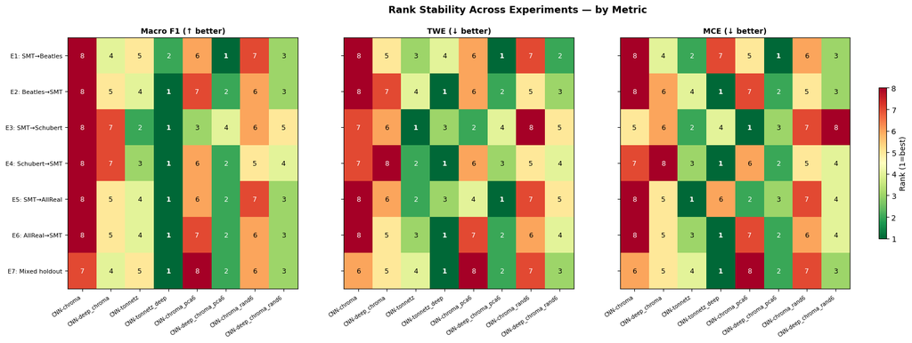

```
Winner per experiment (Macro F1 | TWE | MCE):
Experiment                 Macro F1 winner         TWE winner              MCE winner
-----------------------------------------------------------------------------------------------
E1: SMT→Beatles            CNN-deep_chroma_pca6    CNN-deep_chroma_pca6    CNN-deep_chroma_pca6
E2: Beatles→SMT            CNN-tonnetz_deep        CNN-tonnetz_deep        CNN-tonnetz_deep
E3: SMT→Schubert           CNN-tonnetz_deep        CNN-tonnetz             CNN-chroma_pca6
E4: Schubert→SMT           CNN-tonnetz_deep        CNN-tonnetz_deep        CNN-tonnetz_deep
E5: SMT→AllReal            CNN-tonnetz_deep        CNN-deep_chroma_pca6    CNN-tonnetz
E6: AllReal→SMT            CNN-tonnetz_deep        CNN-tonnetz_deep        CNN-tonnetz_deep
E7: Mixed holdout          CNN-tonnetz_deep        CNN-tonnetz_deep        CNN-tonnetz_deep

--- Domain comparison (by Macro F1) ---
  Pop (E1-E2)              : best avg = CNN-tonnetz_deep (0.5371)
  Classical (E3-E4)        : best avg = CNN-tonnetz_deep (0.4564)
  Mixed (E5-E7)            : best avg = CNN-tonnetz_deep (0.5631)
```

```python
all_experiments = {
    'E1: SMT\u2192Beatles':      results,
    'E2: Beatles\u2192SMT':      exp_e2_res,
    'E3: SMT\u2192Schubert':     exp_e3_res,
    'E4: Schubert\u2192SMT':     exp_e4_res,
    'E5: SMT\u2192AllReal':      exp_e5_res,
    'E6: AllReal\u2192SMT':      exp_e6_res,
    'E7: Mixed holdout':    exp_e7_res,
}

# ── Macro F1 summary table ────────────────────────────────────────────────────
rows = []
for exp_name, exp_res in all_experiments.items():
    row = {'Experiment': exp_name}
    for rep in ALL_REP_DIMS:
        row[f'CNN-{rep}'] = round(exp_res[rep]['macro_f1'], 4)
    row['Best'] = max(ALL_REP_DIMS, key=lambda r: exp_res[r]['macro_f1'])
    rows.append(row)

summary_all = pd.DataFrame(rows)
print('MACRO F1 ACROSS ALL EXPERIMENTS')
print('='*110)
print(summary_all.to_string(index=False))
summary_all.to_csv(str(OUT_DIR / 'all_experiments_macro_f1.csv'), index=False)

# ── Multi-metric rank stability heatmaps ──────────────────────────────────────
# Show separate rank matrices for Macro F1, TWE, and MCE
rank_metrics = [
    ('macro_f1',  'Macro F1 (\u2191 better)', False),
    ('twe',       'TWE (\u2193 better)',       True),
    ('mce',       'MCE (\u2193 better)',       True),
]

exp_names = list(all_experiments.keys())
rep_list  = list(ALL_REP_DIMS.keys())

fig, axes = plt.subplots(1, 3, figsize=(22, 6), gridspec_kw={'right': 0.92})

for ax, (metric_key, metric_title, lower_is_better) in zip(axes, rank_metrics):
    rank_matrix = np.zeros((len(exp_names), len(rep_list)))
    for i, (exp_name, exp_res) in enumerate(all_experiments.items()):
        scores = [exp_res[r][metric_key] for r in rep_list]
        if lower_is_better:
            order = np.argsort(scores)  # ascending = best first for lower-is-better
        else:
            order = np.argsort(scores)[::-1]  # descending = best first for higher-is-better
        ranks = np.zeros(len(rep_list))
        for rank_pos, idx in enumerate(order):
            ranks[idx] = rank_pos + 1
        rank_matrix[i] = ranks

    im = ax.imshow(rank_matrix, cmap='RdYlGn_r', vmin=1, vmax=len(rep_list), aspect='auto')

    ax.set_xticks(range(len(rep_list)))
    ax.set_xticklabels([f'CNN-{r}' for r in rep_list], rotation=35, ha='right', fontsize=7)
    ax.set_yticks(range(len(exp_names)))
    ax.set_yticklabels(exp_names if ax == axes[0] else [], fontsize=8)

    for i in range(len(exp_names)):
        for j in range(len(rep_list)):
            rank = int(rank_matrix[i, j])
            color = 'white' if rank <= 2 or rank >= 7 else 'black'
            fontw = 'bold' if rank == 1 else 'normal'
            ax.text(j, i, str(rank), ha='center', va='center',
                    fontsize=9, color=color, fontweight=fontw)

    ax.set_title(metric_title, fontweight='bold', fontsize=10)

plt.colorbar(im, ax=axes.tolist(), label='Rank (1=best)', shrink=0.6, pad=0.03)
plt.suptitle('Rank Stability Across Experiments — by Metric',
             fontweight='bold', fontsize=13)
plt.tight_layout()
plt.savefig(str(OUT_DIR / 'rank_stability_multi_metric.png'), dpi=150); plt.show()

# ── Winner summary ────────────────────────────────────────────────────────────
print('\nWinner per experiment (Macro F1 | TWE | MCE):')
print(f'{"Experiment":<25s}  {"Macro F1 winner":<22s}  {"TWE winner":<22s}  {"MCE winner":<22s}')
print('-'*95)
for exp_name, exp_res in all_experiments.items():
    best_f1  = max(ALL_REP_DIMS, key=lambda r: exp_res[r]['macro_f1'])
    best_twe = min(ALL_REP_DIMS, key=lambda r: exp_res[r]['twe'])
    best_mce = min(ALL_REP_DIMS, key=lambda r: exp_res[r]['mce'])
    print(f'{exp_name:<25s}  CNN-{best_f1:<18s}  CNN-{best_twe:<18s}  CNN-{best_mce:<18s}')

# ── Domain breakdown ──────────────────────────────────────────────────────────
print('\n--- Domain comparison (by Macro F1) ---')
pop_exps = ['E1: SMT\u2192Beatles', 'E2: Beatles\u2192SMT']
classical_exps = ['E3: SMT\u2192Schubert', 'E4: Schubert\u2192SMT']
mixed_exps = ['E5: SMT\u2192AllReal', 'E6: AllReal\u2192SMT', 'E7: Mixed holdout']

for domain, exps in [('Pop (E1-E2)', pop_exps),
                     ('Classical (E3-E4)', classical_exps),
                     ('Mixed (E5-E7)', mixed_exps)]:
    mean_f1 = {}
    for rep in ALL_REP_DIMS:
        vals = [all_experiments[e][rep]['macro_f1'] for e in exps]
        mean_f1[rep] = np.mean(vals)
    best = max(mean_f1, key=mean_f1.get)
    print(f'  {domain:<25s}: best avg = CNN-{best} ({mean_f1[best]:.4f})')
```

### 10a. Error decomposition across experiments

Decomposing misclassifications into root errors, quality errors, and both-wrong.

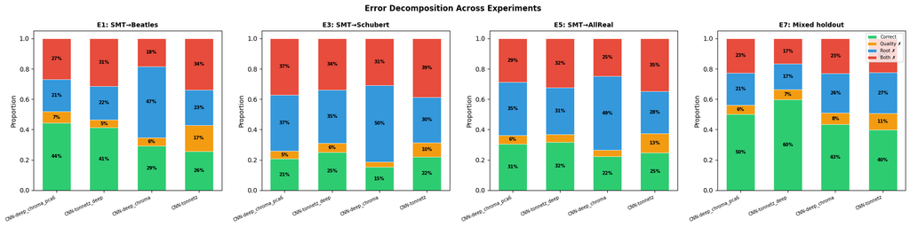

```
Experiment             Model                   Correct  QualErr  RootErr     Both
---------------------------------------------------------------------------
E1: SMT→Beatles        CNN-deep_chroma_pca6      44.3%     7.4%    21.4%    26.8%
E1: SMT→Beatles        CNN-tonnetz_deep          41.2%     5.3%    22.1%    31.4%
E1: SMT→Beatles        CNN-deep_chroma           29.1%     5.5%    47.0%    18.4%
E1: SMT→Beatles        CNN-tonnetz               25.8%    17.1%    23.2%    33.9%

E3: SMT→Schubert       CNN-deep_chroma_pca6      20.6%     5.2%    36.9%    37.2%
E3: SMT→Schubert       CNN-tonnetz_deep          25.2%     6.0%    35.0%    33.8%
E3: SMT→Schubert       CNN-deep_chroma           15.3%     3.5%    50.4%    30.8%
E3: SMT→Schubert       CNN-tonnetz               22.0%     9.5%    29.7%    38.7%

E5: SMT→AllReal        CNN-deep_chroma_pca6      30.6%     5.6%    35.0%    28.8%
E5: SMT→AllReal        CNN-tonnetz_deep          31.8%     4.9%    30.9%    32.5%
E5: SMT→AllReal        CNN-deep_chroma           22.3%     4.1%    48.8%    24.8%
E5: SMT→AllReal        CNN-tonnetz               24.6%    12.9%    27.6%    34.9%

E7: Mixed holdout      CNN-deep_chroma_pca6      50.1%     6.1%    21.2%    22.6%
E7: Mixed holdout      CNN-tonnetz_deep          59.9%     6.7%    16.7%    16.7%
E7: Mixed holdout      CNN-deep_chroma           43.4%     7.6%    25.9%    23.1%
E7: Mixed holdout      CNN-tonnetz               40.0%    10.6%    27.1%    22.4%
```

```python
# ── Error decomposition across ALL experiments ────────────────────────────────
all_exp_for_decomp = {
    'E1: SMT→Beatles':   results,
    'E3: SMT→Schubert':  exp_e3_res,
    'E5: SMT→AllReal':   exp_e5_res,
    'E7: Mixed holdout': exp_e7_res,
}

focus_reps = ['deep_chroma_pca6', 'tonnetz_deep', 'deep_chroma', 'tonnetz']

fig, axes = plt.subplots(1, len(all_exp_for_decomp), figsize=(5*len(all_exp_for_decomp), 5))

for ax, (exp_name, exp_res) in zip(axes, all_exp_for_decomp.items()):
    decomps = {}
    for rep in focus_reps:
        decomps[rep] = error_decomposition(exp_res[rep]['preds'], exp_res[rep]['targets'])

    x = np.arange(len(focus_reps))
    w = 0.6
    bottoms = np.zeros(len(focus_reps))

    err_types = [
        ('correct',     '#2ecc71', 'Correct'),
        ('quality_err', '#f39c12', 'Quality ✗'),
        ('root_err',    '#3498db', 'Root ✗'),
        ('both_err',    '#e74c3c', 'Both ✗'),
    ]
    for key, color, label in err_types:
        vals = [decomps[r][key] for r in focus_reps]
        ax.bar(x, vals, w, bottom=bottoms, label=label, color=color,
               edgecolor='white', linewidth=0.5)
        for i, v in enumerate(vals):
            if v > 0.05:
                ax.text(x[i], bottoms[i] + v/2, f'{v:.0%}',
                        ha='center', va='center', fontsize=7, fontweight='bold')
        bottoms += vals

    ax.set_xticks(x)
    ax.set_xticklabels([f'CNN-{r}' for r in focus_reps], rotation=25, ha='right', fontsize=7)
    ax.set_ylabel('Proportion')
    ax.set_title(exp_name, fontweight='bold', fontsize=10)
    ax.set_ylim(0, 1.05)
    if ax == axes[-1]:
        ax.legend(loc='upper right', fontsize=7)

plt.suptitle('Error Decomposition Across Experiments', fontweight='bold', fontsize=12)
plt.tight_layout()
plt.savefig(str(OUT_DIR / 'error_decomp_all_experiments.png'), dpi=150); plt.show()

# Print table
print(f'\n{"Experiment":<22s} {"Model":<22s} {"Correct":>8s} {"QualErr":>8s} {"RootErr":>8s} {"Both":>8s}')
print('-'*75)
for exp_name, exp_res in all_exp_for_decomp.items():
    for rep in focus_reps:
        d = error_decomposition(exp_res[rep]['preds'], exp_res[rep]['targets'])
        print(f'{exp_name:<22s} CNN-{rep:<18s} {d["correct"]:8.1%} {d["quality_err"]:8.1%} '
              f'{d["root_err"]:8.1%} {d["both_err"]:8.1%}')
    print()
```

### 10b. Comprehensive metric comparison (F1 variants + musical error metrics)

Comparing Macro F1, Micro F1, Weighted F1, TWE, and MCE across experiments tests whether the ranking is robust to the choice of evaluation metric.

```python
# ── Comprehensive metrics comparison across all experiments ───────────────────
def compute_full_metrics(preds, targets):
    acc       = (preds == targets).mean()
    macro_f1  = f1_score(targets, preds, average='macro',    zero_division=0)
    micro_f1  = f1_score(targets, preds, average='micro',    zero_division=0)
    weighted_f1 = f1_score(targets, preds, average='weighted', zero_division=0)
    def twe_dist(p, t):
        ra, qa = IDX2LABEL[p].split(':'); rb, qb = IDX2LABEL[t].split(':')
        return ROOT_DIST[ROOTS.index(ra), ROOTS.index(rb)] + (0.0 if qa == qb else 0.5)
    twe = np.mean([twe_dist(int(p), int(t)) for p, t in zip(preds, targets)])
    def mce_dist(p, t):
        ra, qa = IDX2LABEL[p].split(':'); rb, qb = IDX2LABEL[t].split(':')
        ia, ib = ROOTS.index(ra), ROOTS.index(rb)
        interval = (ib - ia) % 12
        return float(CONSONANCE_VEC[interval]) + (0.0 if qa == qb else 1.0)
    mce = np.mean([mce_dist(int(p), int(t)) for p, t in zip(preds, targets)])
    return dict(acc=acc, macro_f1=macro_f1, micro_f1=micro_f1,
                weighted_f1=weighted_f1, twe=twe, mce=mce)

exp_dict = {
    'E1: SMT→Beatles':   results,
    'E3: SMT→Schubert':  exp_e3_res,
    'E5: SMT→AllReal':   exp_e5_res,
    'E7: Mixed holdout': exp_e7_res,
}

all_exp_metrics = {}
for exp_name, exp_res in exp_dict.items():
    all_exp_metrics[exp_name] = {}
    for rep in focus_reps:
        all_exp_metrics[exp_name][rep] = compute_full_metrics(
            exp_res[rep]['preds'], exp_res[rep]['targets'])

# Print tables
metrics_list = ['macro_f1', 'micro_f1', 'weighted_f1', 'twe', 'mce']
metric_labels = {'macro_f1': 'Macro F1', 'micro_f1': 'Micro F1',
                 'weighted_f1': 'Wt. F1', 'twe': 'TWE ↓', 'mce': 'MCE ↓'}

for exp_name in exp_dict:
    print(f'\n{"="*85}')
    print(f'{exp_name}')
    print(f'{"="*85}')
    header = f'{"Model":<22s}'
    for m in metrics_list:
        header += f'  {metric_labels[m]:>10s}'
    print(header)
    print('-'*85)
    for rep in focus_reps:
        d = all_exp_metrics[exp_name][rep]
        row = f'CNN-{rep:<18s}'
        for m in metrics_list:
            row += f'  {d[m]:10.4f}'
        print(row)

# Winner matrix
print('\n\nWINNER MATRIX (metric × experiment):')
exp_short = ['SMT→Beatles', 'SMT→Schubert', 'SMT→AllReal', 'Mixed Holdout']
print(f'{"Metric":<15s}', end='')
for e in exp_short:
    print(f'  {e:>12s}', end='')
print()
print('-'*70)
for m in metrics_list:
    print(f'{metric_labels[m]:<15s}', end='')
    for exp_name in exp_dict:
        if 'twe' in m or 'mce' in m:
            best = min(focus_reps, key=lambda r: all_exp_metrics[exp_name][r][m])
        else:
            best = max(focus_reps, key=lambda r: all_exp_metrics[exp_name][r][m])
        short = best.replace('deep_chroma_', 'dc_').replace('tonnetz', 'tz')
        print(f'  {short:>12s}', end='')
    print()
```

```
=====================================================================================
E1: SMT→Beatles
=====================================================================================
Model                     Macro F1    Micro F1      Wt. F1       TWE ↓       MCE ↓
-------------------------------------------------------------------------------------
CNN-deep_chroma_pca6        0.3897      0.4433      0.4519      1.1858      1.6957
CNN-tonnetz_deep            0.3537      0.4124      0.4465      1.4120      2.3531
CNN-deep_chroma             0.2555      0.2912      0.3118      1.5406      2.1469
CNN-tonnetz                 0.2209      0.2576      0.2893      1.4069      1.8445

=====================================================================================
E3: SMT→Schubert
=====================================================================================
Model                     Macro F1    Micro F1      Wt. F1       TWE ↓       MCE ↓
-------------------------------------------------------------------------------------
CNN-deep_chroma_pca6        0.1871      0.2065      0.2195      1.7780      2.5211
CNN-tonnetz_deep            0.2239      0.2515      0.2590      1.7155      2.5935
CNN-deep_chroma             0.1116      0.1527      0.1423      1.9178      2.7258
CNN-tonnetz                 0.2147      0.2200      0.2424      1.6883      2.4529

=====================================================================================
E5: SMT→AllReal
=====================================================================================
Model                     Macro F1    Micro F1      Wt. F1       TWE ↓       MCE ↓
-------------------------------------------------------------------------------------
CNN-deep_chroma_pca6        0.2899      0.3057      0.3156      1.5391      2.2733
CNN-tonnetz_deep            0.3111      0.3180      0.3371      1.6033      2.5875
CNN-deep_chroma             0.2012      0.2230      0.2295      1.7308      2.4367
CNN-tonnetz                 0.2340      0.2458      0.2550      1.5393      2.1263

=====================================================================================
E7: Mixed holdout
=====================================================================================
Model                     Macro F1    Micro F1      Wt. F1       TWE ↓       MCE ↓
-------------------------------------------------------------------------------------
CNN-deep_chroma_pca6        0.4050      0.5006      0.5015      1.0349      1.3311
CNN-tonnetz_deep            0.5060      0.5987      0.6031      0.8191      1.1416
CNN-deep_chroma             0.3612      0.4338      0.4469      1.1889      1.6775
CNN-tonnetz                 0.3430      0.3995      0.4107      1.1782      1.5782


WINNER MATRIX (metric × experiment):
Metric            SMT→Beatles  SMT→Schubert   SMT→AllReal  Mixed Holdout
----------------------------------------------------------------------
Macro F1              dc_pca6       tz_deep       tz_deep       tz_deep
Micro F1              dc_pca6       tz_deep       tz_deep       tz_deep
Wt. F1                dc_pca6       tz_deep       tz_deep       tz_deep
TWE ↓                 dc_pca6            tz       dc_pca6       tz_deep
MCE ↓                 dc_pca6            tz            tz       tz_deep
```

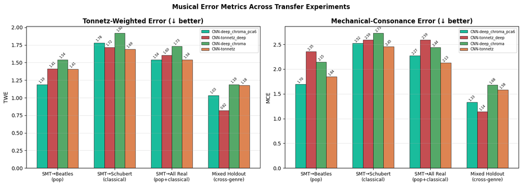

```python
# ── Musical error metrics across experiments ──────────────────────────────────
exp_names_short = ['SMT\u2192Beatles\n(pop)', 'SMT\u2192Schubert\n(classical)', 'SMT\u2192All Real\n(pop+classical)', 'Mixed Holdout\n(cross-genre)']
x = np.arange(len(exp_names_short))
w = 0.18

fig, axes = plt.subplots(1, 2, figsize=(14, 5))
for ax, metric, title in zip(axes, ['twe', 'mce'],
    ['Tonnetz-Weighted Error (↓ better)', 'Mechanical-Consonance Error (↓ better)']):
    for i, rep in enumerate(focus_reps):
        vals = [all_exp_metrics[e][rep][metric] for e in exp_dict]
        ax.bar(x + i*w, vals, w, label=f'CNN-{rep}', color=ALL_COLORS[rep],
               edgecolor='black', linewidth=0.5)
        for j, v in enumerate(vals):
            ax.text(x[j] + i*w, v + 0.02, f'{v:.2f}', ha='center', fontsize=6, rotation=45)
    ax.set_xticks(x + w*1.5)
    ax.set_xticklabels(exp_names_short, fontsize=9)
    ax.set_ylabel(metric.upper())
    ax.set_title(title, fontweight='bold')
    ax.legend(fontsize=7)
    ax.grid(axis='y', alpha=0.3)

plt.suptitle('Musical Error Metrics Across Transfer Experiments', fontweight='bold')
plt.tight_layout()
plt.savefig(str(OUT_DIR / 'musical_errors_all_experiments.png'), dpi=150); plt.show()
```

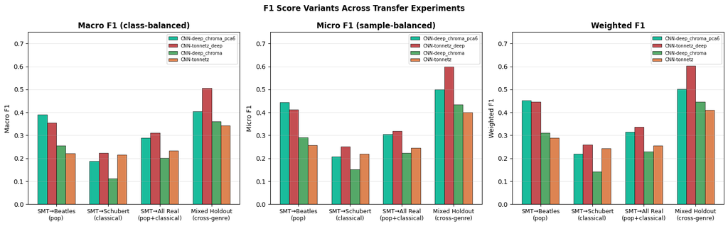

```python
# ── F1 score variants across experiments ──────────────────────────────────────
fig, axes = plt.subplots(1, 3, figsize=(16, 5))
f1_metrics = ['macro_f1', 'micro_f1', 'weighted_f1']
f1_titles = ['Macro F1 (class-balanced)', 'Micro F1 (sample-balanced)', 'Weighted F1']

for ax, metric, title in zip(axes, f1_metrics, f1_titles):
    for i, rep in enumerate(focus_reps):
        vals = [all_exp_metrics[e][rep][metric] for e in exp_dict]
        ax.bar(x + i*w, vals, w, label=f'CNN-{rep}', color=ALL_COLORS[rep],
               edgecolor='black', linewidth=0.5)
    ax.set_xticks(x + w*1.5)
    ax.set_xticklabels(exp_names_short, fontsize=9)
    ax.set_ylabel(metric.replace('_', ' ').title())
    ax.set_title(title, fontweight='bold')
    ax.set_ylim(0, 0.75)
    ax.legend(fontsize=7)
    ax.grid(axis='y', alpha=0.3)

plt.suptitle('F1 Score Variants Across Transfer Experiments', fontweight='bold')
plt.tight_layout()
plt.savefig(str(OUT_DIR / 'f1_variants_all_experiments.png'), dpi=150); plt.show()
```

### 10c. Domain-dependent representation advantage

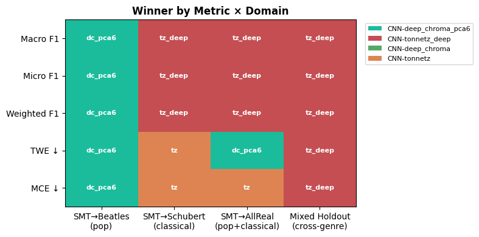

```
Beatles: deep_chroma_pca6 sweeps all metrics
Schubert/AllReal/Mixed: tonnetz variants dominate
→ The optimal representation depends on harmonic complexity.
```

```python
# ── Heatmap: which representation wins each metric × experiment? ───────────────
metric_names = ['Macro F1', 'Micro F1', 'Weighted F1', 'TWE ↓', 'MCE ↓']
metric_keys  = ['macro_f1', 'micro_f1', 'weighted_f1', 'twe', 'mce']
exp_labels   = ['SMT\u2192Beatles\n(pop)', 'SMT\u2192Schubert\n(classical)', 'SMT\u2192AllReal\n(pop+classical)', 'Mixed Holdout\n(cross-genre)']

# Build winner matrix as numeric (0=dc_pca6, 1=tz_deep, 2=dc, 3=tz)
rep_to_idx = {r: i for i, r in enumerate(focus_reps)}
winner_matrix = np.zeros((len(metric_keys), len(exp_dict)))

for j, exp_name in enumerate(exp_dict):
    for i, m in enumerate(metric_keys):
        if 'twe' in m or 'mce' in m:
            best = min(focus_reps, key=lambda r: all_exp_metrics[exp_name][r][m])
        else:
            best = max(focus_reps, key=lambda r: all_exp_metrics[exp_name][r][m])
        winner_matrix[i, j] = rep_to_idx[best]

fig, ax = plt.subplots(figsize=(8, 4))
cmap = plt.cm.colors.ListedColormap([ALL_COLORS[r] for r in focus_reps])
im = ax.imshow(winner_matrix, cmap=cmap, vmin=-0.5, vmax=len(focus_reps)-0.5, aspect='auto')

ax.set_xticks(range(len(exp_labels)))
ax.set_xticklabels(exp_labels, fontsize=10)
ax.set_yticks(range(len(metric_names)))
ax.set_yticklabels(metric_names, fontsize=10)

# Add text labels
short_names = {r: r.replace('deep_chroma_', 'dc_').replace('tonnetz', 'tz') for r in focus_reps}
for i in range(len(metric_keys)):
    for j in range(len(exp_dict)):
        rep = focus_reps[int(winner_matrix[i, j])]
        ax.text(j, i, short_names[rep], ha='center', va='center',
                fontsize=8, fontweight='bold', color='white')

# Legend
from matplotlib.patches import Patch
legend_handles = [Patch(facecolor=ALL_COLORS[r], label=f'CNN-{r}') for r in focus_reps]
ax.legend(handles=legend_handles, loc='upper left', bbox_to_anchor=(1.02, 1),
          fontsize=8, frameon=True)

ax.set_title('Winner by Metric × Domain', fontweight='bold', fontsize=12)
plt.tight_layout()
plt.savefig(str(OUT_DIR / 'winner_heatmap.png'), dpi=150, bbox_inches='tight'); plt.show()

print('Beatles: deep_chroma_pca6 sweeps all metrics')
print('Schubert/AllReal/Mixed: tonnetz variants dominate')
print('→ The optimal representation depends on harmonic complexity.')
```

### 10d. Random projection stability check

Our single random-6 projection uses a fixed seed, it could be an unusually good or bad draw. To verify that Tonnetz and PCA genuinely outperform random projections, we run 20 random orthonormal projections on **E1 (SMT→Beatles), E3 (SMT→Schubert), E7 (Mixed holdout)**

```
============================================================
E1: SMT→Beatles: Running 20 random projections...
============================================================
  epoch  10/40  train=1.1307  val=1.7003  acc=0.4514
  epoch  20/40  train=0.6159  val=2.1597  acc=0.4094
  epoch  30/40  train=0.4093  val=0.8971  acc=0.7323
  epoch  40/40  train=0.3808  val=0.8112  acc=0.7559
  epoch  10/40  train=0.6690  val=0.9515  acc=0.7559
  epoch  20/40  train=0.3812  val=0.6488  acc=0.8189
  epoch  30/40  train=0.2414  val=0.4804  acc=0.9003
  epoch  40/40  train=0.2031  val=0.4374  acc=0.9081
  epoch  10/40  train=1.0715  val=2.4623  acc=0.2546
  epoch  20/40  train=0.6019  val=1.4356  acc=0.5591
  epoch  30/40  train=0.4192  val=0.9394  acc=0.7349
  epoch  40/40  train=0.3596  val=0.8336  acc=0.7717
  epoch  10/40  train=0.5792  val=0.9548  acc=0.7113
  epoch  20/40  train=0.3083  val=0.8172  acc=0.8163
  epoch  30/40  train=0.1708  val=0.5211  acc=0.8845
  epoch  40/40  train=0.1389  val=0.4859  acc=0.8898
  epoch  10/40  train=1.1537  val=1.6602  acc=0.5249
  epoch  20/40  train=0.5922  val=1.1791  acc=0.6745
  epoch  30/40  train=0.4180  val=1.0032  acc=0.7270
  epoch  40/40  train=0.3824  val=0.7907  acc=0.7874
  epoch  10/40  train=0.5600  val=0.9509  acc=0.7612
  epoch  20/40  train=0.2745  val=0.6493  acc=0.8661
  epoch  30/40  train=0.1582  val=0.5061  acc=0.8845
  epoch  40/40  train=0.1323  val=0.4717  acc=0.9029
  epoch  10/40  train=1.2322  val=1.8975  acc=0.4252
  epoch  20/40  train=0.6694  val=1.4694  acc=0.5879
  epoch  30/40  train=0.4790  val=1.0500  acc=0.6745
  epoch  40/40  train=0.4009  val=0.9210  acc=0.7559
  epoch  10/40  train=0.5901  val=0.6889  acc=0.8268
  epoch  20/40  train=0.3143  val=0.7962  acc=0.7953
  epoch  30/40  train=0.1733  val=0.5034  acc=0.8740
  epoch  40/40  train=0.1452  val=0.4865  acc=0.8845
  epoch  10/40  train=1.0178  val=1.6426  acc=0.5118
  epoch  20/40  train=0.5727  val=1.8323  acc=0.4908
  epoch  30/40  train=0.3813  val=0.9318  acc=0.7559
  epoch  40/40  train=0.3443  val=0.8592  acc=0.7507
  epoch  10/40  train=0.6776  val=1.0267  acc=0.7638
```

[output cut: 448 more lines]

```
  epoch  30/40  train=0.8640  val=1.0004  acc=0.7244
  epoch  40/40  train=0.7710  val=0.8287  acc=0.7769
  epoch  10/40  train=1.2165  val=0.9164  acc=0.7638
  epoch  20/40  train=0.8654  val=0.8048  acc=0.7874
  epoch  30/40  train=0.6325  val=0.4999  acc=0.8688
  epoch  40/40  train=0.5456  val=0.4540  acc=0.8898
  epoch  10/40  train=1.7309  val=2.0029  acc=0.3885
  epoch  20/40  train=1.2620  val=1.3973  acc=0.5984
  epoch  30/40  train=0.9057  val=1.6086  acc=0.5013
  epoch  40/40  train=0.8303  val=1.0491  acc=0.7060
  epoch  10/40  train=1.0610  val=1.7407  acc=0.4593
  epoch  20/40  train=0.7153  val=1.0740  acc=0.7349
  epoch  30/40  train=0.4921  val=0.4891  acc=0.9081
  epoch  40/40  train=0.4384  val=0.4365  acc=0.9108
  Trial 20/20 done
```

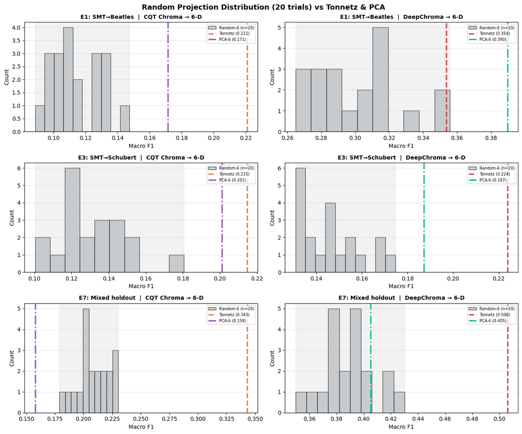

```
====================================================================================================
RANDOM PROJECTION STABILITY SUMMARY
====================================================================================================
Experiment             Chroma          Rand Mean   Rand Std    Tonnetz      PCA-6   #Beat Tz  #Beat PCA
----------------------------------------------------------------------------------------------------
E1: SMT→Beatles        chroma             0.1141     0.0144     0.2209     0.1714       0/20        0/20
E1: SMT→Beatles        deep_chroma        0.3011     0.0249     0.3537     0.3897       1/20        0/20

E3: SMT→Schubert       chroma             0.1312     0.0184     0.2147     0.2011       0/20        0/20
E3: SMT→Schubert       deep_chroma        0.1457     0.0132     0.2239     0.1871       0/20        0/20

E7: Mixed holdout      chroma             0.2084     0.0139     0.3430     0.1578       0/20       20/20
E7: Mixed holdout      deep_chroma        0.3888     0.0186     0.5060     0.4050       0/20        3/20
```

```python
# ── Random projection stability check — E1, E3, and E7 ────────────────────────
# Run 20 random orthonormal projections per experiment to verify that
# Tonnetz/PCA advantages aren't explained by a lucky random draw.
#
# E1 (Beatles): PCA wins, is PCA above the random distribution?
# E3 (Schubert): Tonnetz wins, is Tonnetz above the random distribution?
# E7 (Mixed holdout): Tonnetz_deep wins by wide margin, is it above random?

N_RANDOM = 20

experiments_to_check = {
    'E1: SMT\u2192Beatles':    (smt_data, beatles_data, None),
    'E3: SMT\u2192Schubert':   (smt_data, schubert_data, None),
    'E7: Mixed holdout':  (mixed_train_e7, mixed_test_e7, smt_val_e7),
}

rand_results = {}

for exp_name, (train_data, test_data, val_data) in experiments_to_check.items():
    print(f'\n{"="*60}')
    print(f'{exp_name}: Running {N_RANDOM} random projections...')
    print(f'{"="*60}')

    rand_f1s = {'chroma': [], 'deep_chroma': []}

    for trial in range(N_RANDOM):
        rng_trial = np.random.default_rng(trial * 7 + 1)

        for src in ['chroma', 'deep_chroma']:
            Q, _ = np.linalg.qr(rng_trial.standard_normal((12, 6)))

            N_tr, T, F = train_data[src].shape
            train_proj = (train_data[src].reshape(-1, F) @ Q).reshape(N_tr, T, 6).astype(np.float32)
            N_te = test_data[src].shape[0]
            test_proj = (test_data[src].reshape(-1, F) @ Q).reshape(N_te, T, 6).astype(np.float32)

            train_d = {'rand_proj': train_proj, 'labels': train_data['labels']}
            test_d  = {'rand_proj': test_proj,  'labels': test_data['labels']}

            # If val_data provided, project that too
            if val_data is not None:
                N_v = val_data[src].shape[0]
                val_proj = (val_data[src].reshape(-1, F) @ Q).reshape(N_v, T, 6).astype(np.float32)
                val_d = {'rand_proj': val_proj, 'labels': val_data['labels']}
                tl, vl = make_loaders(train_d, 'rand_proj', val_data=val_d)
            else:
                tl, vl = make_loaders(train_d, 'rand_proj')

            torch.manual_seed(SEED)
            model, _ = train_model('rand_proj', 6, tl, vl, epochs=EPOCHS)
            preds, targets = evaluate(model, make_test_loader(test_d, 'rand_proj'))
            f1 = f1_score(targets, preds, average='macro', zero_division=0)
            rand_f1s[src].append(f1)

        if (trial + 1) % 5 == 0:
            print(f'  Trial {trial+1}/{N_RANDOM} done')

    rand_results[exp_name] = rand_f1s

# ── Reference values ──────────────────────────────────────────────────────────
ref_values = {
    'E1: SMT\u2192Beatles':    results,
    'E3: SMT\u2192Schubert':   exp_e3_res,
    'E7: Mixed holdout':  exp_e7_res,
}

# ── Visualization: 3x2 grid (experiment × chroma type) ───────────────────────
fig, axes = plt.subplots(3, 2, figsize=(13, 11))

for row, (exp_name, rand_f1s) in enumerate(rand_results.items()):
    exp_res = ref_values[exp_name]

    for col, (src, src_label) in enumerate([('chroma', 'CQT Chroma'),
                                             ('deep_chroma', 'DeepChroma')]):
        ax = axes[row][col]
        tz_key  = 'tonnetz' if src == 'chroma' else 'tonnetz_deep'
        pca_key = 'chroma_pca6' if src == 'chroma' else 'deep_chroma_pca6'

        tz_f1  = exp_res[tz_key]['macro_f1']
        pca_f1 = exp_res[pca_key]['macro_f1']

        ax.hist(rand_f1s[src], bins=10, color='#BDC3C7', edgecolor='black',
                alpha=0.7, label=f'Random-6 (n={N_RANDOM})')
        ax.axvline(tz_f1, color=ALL_COLORS[tz_key], lw=2.5, ls='--',
                   label=f'Tonnetz ({tz_f1:.3f})')
        ax.axvline(pca_f1, color=ALL_COLORS[pca_key], lw=2.5, ls='-.',
                   label=f'PCA-6 ({pca_f1:.3f})')
        ax.axvspan(min(rand_f1s[src]), max(rand_f1s[src]),
                   alpha=0.1, color='grey')

        ax.set_xlabel('Macro F1')
        ax.set_ylabel('Count')
        ax.set_title(f'{exp_name}  |  {src_label} \u2192 6-D', fontweight='bold', fontsize=10)
        ax.legend(fontsize=7, loc='upper right')
        ax.grid(axis='y', alpha=0.3)

plt.suptitle(f'Random Projection Distribution ({N_RANDOM} trials) vs Tonnetz & PCA',
             fontweight='bold', fontsize=13)
plt.tight_layout()
plt.savefig(str(OUT_DIR / 'random_projection_stability.png'), dpi=150); plt.show()

# ── Summary table ─────────────────────────────────────────────────────────────
print(f'\n{"="*100}')
print(f'RANDOM PROJECTION STABILITY SUMMARY')
print(f'{"="*100}')
print(f'{"Experiment":<22s} {"Chroma":<14s} {"Rand Mean":>10s} {"Rand Std":>10s} '
      f'{"Tonnetz":>10s} {"PCA-6":>10s} {"#Beat Tz":>10s} {"#Beat PCA":>10s}')
print('-'*100)

for exp_name, rand_f1s in rand_results.items():
    exp_res = ref_values[exp_name]
    for src in ['chroma', 'deep_chroma']:
        tz_key  = 'tonnetz' if src == 'chroma' else 'tonnetz_deep'
        pca_key = 'chroma_pca6' if src == 'chroma' else 'deep_chroma_pca6'
        tz_f1  = exp_res[tz_key]['macro_f1']
        pca_f1 = exp_res[pca_key]['macro_f1']
        r = rand_f1s[src]
        n_beat_tz  = sum(1 for f in r if f > tz_f1)
        n_beat_pca = sum(1 for f in r if f > pca_f1)
        print(f'{exp_name:<22s} {src:<14s} {np.mean(r):10.4f} {np.std(r):10.4f} '
              f'{tz_f1:10.4f} {pca_f1:10.4f} {n_beat_tz:>7d}/{N_RANDOM}  {n_beat_pca:>7d}/{N_RANDOM}')
    print()
```